# MIMIC-III Will Files Parse?

Check to see if records in MIMIC-III comma-separated value files parse to same number of tokens.

The result of this exercise tells us the number of lines, records and fields in each file.

efg | 2018-07-08

```r
suppressPackageStartupMessages( library(dplyr) )   # select, group_by, ...
library(kableExtra)  # kable_styling
library(tibble)      # tibble
```

## Make list of .csv data files

```r
dataDIR <- "../../data/"
files <- list.files(dataDIR, full.names=TRUE)
```

## Count fields in each file

```r
summary <- tibble(Filename=substr(files, 12, nchar(files)),
                  Lines=0,
                  Records=0,
                  Fields=0)
```

```r
for (i in 1:length(files))
{
  cat(i, files[i], "\n")
  fieldCounts <- count.fields(files[i], sep=",", comment.char="", quote='"')

  frequency <- table(fieldCounts, useNA="ifany")
  if (length(frequency) > 1)  # all should parse into same number of fields
  {
    print(frequency)
  }

  summary$Lines[i]   <- length(fieldCounts)
  summary$Records[i] <- frequency[1]   # get lucky for now that NA count is second
  summary$Fields[i]  <- as.numeric(names(frequency)[1])
}
```

```
1 ../../data/ADMISSIONS.csv
2 ../../data/CALLOUT.csv
3 ../../data/CAREGIVERS.csv
4 ../../data/CHARTEVENTS.csv
5 ../../data/CPTEVENTS.csv
6 ../../data/D_CPT.csv
7 ../../data/D_ICD_DIAGNOSES.csv
8 ../../data/D_ICD_PROCEDURES.csv
9 ../../data/D_ITEMS.csv
10 ../../data/D_LABITEMS.csv
11 ../../data/DATETIMEEVENTS.csv
12 ../../data/DIAGNOSES_ICD.csv
13 ../../data/DRGCODES.csv
14 ../../data/ICUSTAYS.csv
15 ../../data/INPUTEVENTS_CV.csv
16 ../../data/INPUTEVENTS_MV.csv
17 ../../data/LABEVENTS.csv
18 ../../data/MICROBIOLOGYEVENTS.csv
19 ../../data/NOTEEVENTS.csv
fieldCounts
      11     <NA>
 2083181 89609128
20 ../../data/OUTPUTEVENTS.csv
21 ../../data/PATIENTS.csv
22 ../../data/PRESCRIPTIONS.csv
23 ../../data/PROCEDUREEVENTS_MV.csv
24 ../../data/PROCEDURES_ICD.csv
25 ../../data/SERVICES.csv
26 ../../data/TRANSFERS.csv
```

NOTEEVENTS shows a curious problem with field counts with most being NA. What does that mean?

```r
summary                                                                  %>%
  kable("html", format.args=list(big.mark=","))                          %>%
  kable_styling(bootstrap_options=c("striped", "bordered", "condensed"),
                position="left", full_width=FALSE)
```

| Filename | Lines | Records | Fields |
| --- | --- | --- | --- |
| ADMISSIONS.csv | 58,977 | 58,977 | 19 |
| CALLOUT.csv | 34,500 | 34,500 | 24 |
| CAREGIVERS.csv | 7,568 | 7,568 | 4 |
| CHARTEVENTS.csv | 330,712,484 | 330,712,484 | 15 |
| CPTEVENTS.csv | 573,147 | 573,147 | 12 |
| D_CPT.csv | 135 | 135 | 9 |
| D_ICD_DIAGNOSES.csv | 14,568 | 14,568 | 4 |
| D_ICD_PROCEDURES.csv | 3,883 | 3,883 | 4 |
| D_ITEMS.csv | 12,488 | 12,488 | 10 |
| D_LABITEMS.csv | 754 | 754 | 6 |
| DATETIMEEVENTS.csv | 4,485,938 | 4,485,938 | 14 |
| DIAGNOSES_ICD.csv | 651,048 | 651,048 | 5 |
| DRGCODES.csv | 125,558 | 125,558 | 8 |
| ICUSTAYS.csv | 61,533 | 61,533 | 12 |
| INPUTEVENTS_CV.csv | 17,527,936 | 17,527,936 | 22 |
| INPUTEVENTS_MV.csv | 3,618,992 | 3,618,992 | 31 |
| LABEVENTS.csv | 27,854,056 | 27,854,056 | 9 |
| MICROBIOLOGYEVENTS.csv | 631,727 | 631,727 | 16 |
| NOTEEVENTS.csv | 91,692,309 | 2,083,181 | 11 |
| OUTPUTEVENTS.csv | 4,349,219 | 4,349,219 | 13 |
| PATIENTS.csv | 46,521 | 46,521 | 8 |
| PRESCRIPTIONS.csv | 4,156,451 | 4,156,451 | 19 |
| PROCEDUREEVENTS_MV.csv | 258,067 | 258,067 | 25 |
| PROCEDURES_ICD.csv | 240,096 | 240,096 | 5 |
| SERVICES.csv | 73,344 | 73,344 | 6 |
| TRANSFERS.csv | 261,898 | 261,898 | 13 |

Except for NOTEEVENTS, the lines count returned by *count.fields* matches the number of number of line feeds (x0A characters) from character counts.

Initially, it’s unclear why info from *count.fields* suggests NOTEEVETNS has 91,692,309 lines (vs. the 91,691,299 line feeds from character count) with 2,083,181 logical records.

Let’s explore the reason for all the NAs in the field counts of NOTEEVENTS.

The *?count.fields* help says:

```
Consistent with scan, count.fields allows quoted strings to contain newline characters.
In such a case the starting line will have the field count recorded as NA, and the ending
line will include the count of all fields from the beginning of the record.
```

Can we verify that lines are wrapping to get 11 fields in each record?

```r
fieldCounts <- count.fields("../../data/NOTEEVENTS.csv", sep=",", comment.char="", quote='"')
frequency <- table(fieldCounts, useNA="ifany")
frequency
```

[output not shown]

The problem shows up in the first few records. Oddly, the second *count.fields* non-NA value appears on line 31. What’s going on here?

```r
head(fieldCounts,31)
```

```
 [1] 11 NA NA NA NA NA NA NA NA NA NA NA NA NA NA NA NA NA NA NA NA NA NA NA NA NA NA NA NA NA 11
```

What do the first 32 lines look like? Let’s read all fields as character strings.

```r
s <- readLines("../../data/NOTEEVENTS.csv", n=32)
s
```

```
 [1] "\"ROW_ID\",\"SUBJECT_ID\",\"HADM_ID\",\"CHARTDATE\",\"CHARTTIME\",\"STORETIME\",\"CATEGORY\",\"DESCRIPTION\",\"CGID\",\"ISERROR\",\"TEXT\""
 [2] "174,22532,167853,2151-08-04,,,\"Discharge summary\",\"Report\",,,\"Admission Date:  [**2151-7-16**]       Discharge Date:  [**2151-8-4**]"
 [3] ""
 [4] ""
 [5] "Service:"
 [6] "ADDENDUM:"
 [7] ""
 [8] "RADIOLOGIC STUDIES:  Radiologic studies also included a chest"
 [9] "CT, which confirmed cavitary lesions in the left lung apex"
[10] "consistent with infectious process/tuberculosis.  This also"
[11] "moderate-sized left pleural effusion."
[12] ""
[13] "HEAD CT:  Head CT showed no intracranial hemorrhage or mass"
[14] "effect, but old infarction consistent with past medical"
[15] "history."
```

[output cut: 17 more lines]

R is adding a lot of quotes above, so let’s use the command-line *head* command to see the “real” raw data …

```
F:\MIMIC-III\data>head -31 NOTEEVENTS.csv
"ROW_ID","SUBJECT_ID","HADM_ID","CHARTDATE","CHARTTIME","STORETIME","CATEGORY","DESCRIPTION","CGID","ISERROR","TEXT"
174,22532,167853,2151-08-04,,,"Discharge summary","Report",,,"Admission Date:  [**2151-7-16**]       Discharge Date:  [**2151-8-4**]


Service:
ADDENDUM:

RADIOLOGIC STUDIES:  Radiologic studies also included a chest
CT, which confirmed cavitary lesions in the left lung apex
consistent with infectious process/tuberculosis.  This also
moderate-sized left pleural effusion.

HEAD CT:  Head CT showed no intracranial hemorrhage or mass
effect, but old infarction consistent with past medical
history.

ABDOMINAL CT:  Abdominal CT showed lesions of
T10 and sacrum most likely secondary to osteoporosis. These can
be followed by repeat imaging as an outpatient.



                            [**First Name8 (NamePattern2) **] [**First Name4 (NamePattern1) 1775**] [**Last Name (NamePattern1) **], M.D.  [**MD Number(1) 1776*
*]

Dictated By:[**Hospital 1807**]
MEDQUIST36

D:  [**2151-8-5**]  12:11
T:  [**2151-8-5**]  12:21
JOB#:  [**Job Number 1808**]
"
```

Not there is an “opening” quote on line two (“Admission …) that is not closed until the final quote on line 31. This wrapped, multi-line field is a single TEXT field with a report.

This report gives clues about how the original information was de-identified for public release.

```r
d <- read.csv("../../data/NOTEEVENTS.csv", colClasses="character", nrows=1)
```

```r
d                    %>%
  kable("html")      %>%
  kable_styling(bootstrap_options=c("striped", "bordered", "condensed"),
                position="left", full_width=TRUE)
```

| ROW_ID | SUBJECT_ID | HADM_ID | CHARTDATE | CHARTTIME | STORETIME | CATEGORY | DESCRIPTION | CGID | ISERROR | TEXT |
| --- | --- | --- | --- | --- | --- | --- | --- | --- | --- | --- |
| 174 | 22532 | 167853 | 2151-08-04 |  |  | Discharge summary | Report |  |  | Admission Date: [**2151-7-16**] Discharge Date: [**2151-8-4**] Service: ADDENDUM: RADIOLOGIC STUDIES: Radiologic studies also included a chest CT, which confirmed cavitary lesions in the left lung ape… |

```r
str(d)
```

```
'data.frame':   1 obs. of  11 variables:
 $ ROW_ID     : chr "174"
 $ SUBJECT_ID : chr "22532"
 $ HADM_ID    : chr "167853"
 $ CHARTDATE  : chr "2151-08-04"
 $ CHARTTIME  : chr ""
 $ STORETIME  : chr ""
 $ CATEGORY   : chr "Discharge summary"
 $ DESCRIPTION: chr "Report"
 $ CGID       : chr ""
 $ ISERROR    : chr ""
 $ TEXT       : chr "Admission Date:  [**2151-7-16**]       Discharge Date:  [**2151-8-4**]\n\n\nService:\nADDENDUM:\n\nRADIOLOGIC S"| __truncated__
```

The file consists of many multi-line logical records. Can we justify the count of 2,083,181 records with 11 fields each?

Can we load the whole 3.7 GB NOTEEVENTS.csv into memory using R with 32 GB memory? Yes!

Let’s use the readr function *read_csv*, which should be more efficient thant *read.csv*.

```r
library(readr)
d <- read_csv("../../data/NOTEEVENTS.csv", progress=FALSE)
```

[output not shown]

```r
dim(d)
```

```
[1] 2083180      11
```

The CATEGORY variable seems to be defined in all records:

```r
counts <-
  d                   %>%
  group_by(CATEGORY)  %>%
  summarize(n=n())
```

```r
counts                                                                    %>%
   kable("html", format.args=list(big.mark=","))                          %>%
  kable_styling(bootstrap_options=c("striped", "bordered", "condensed"),
                position="left", full_width=FALSE)
```

| CATEGORY | n |
| --- | --- |
| Case Management | 967 |
| Consult | 98 |
| Discharge summary | 59,652 |
| ECG | 209,051 |
| Echo | 45,794 |
| General | 8,301 |
| Nursing | 223,556 |
| Nursing/other | 822,497 |
| Nutrition | 9,418 |
| Pharmacy | 103 |
| Physician | 141,624 |
| Radiology | 522,279 |
| Rehab Services | 5,431 |
| Respiratory | 31,739 |
| Social Work | 2,670 |

The total is about what is expected:

```r
sum(counts$n)
```

```
[1] 2083180
```

*read_csv* found 2,083,180 logical records of 11 fields. The original count was one more because of the header row.

We conclude there are 2,083,180 NOTEEVENT records with 11 fields, and parsing the MIMIC-III files should not be a problem (as long as multi-line records are allowed).

How variable is the length of the TEXT fields?

```r
fivenum(nchar(d$TEXT))
```

```
[1]     3   426  1093  1864 55728
```

The distribution is a bit skewed, and pehaps multi-modal, which is shown by the density plot. Perhaps there are different kinds of TEXT reports based on length alone?

Log scaling is used to make the skewed distribution a bit more “log normal”.

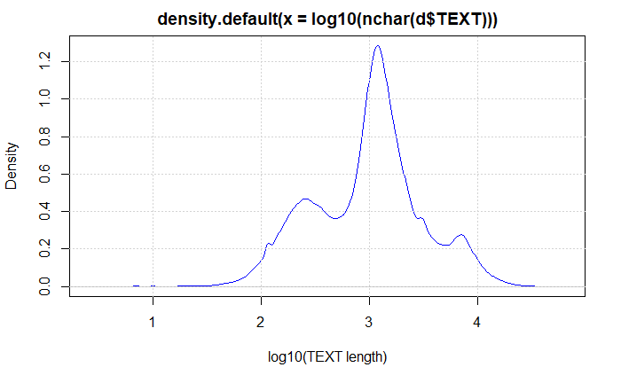

```r
plot(density(log10(nchar(d$TEXT))), col="blue", xlab="log10(TEXT length)")
grid()
```

Processing time: 2509.1 secs

2018-07-08 0101